# Project ALS — Natural Language Database Access

Benchmarking Local LLMs for Genomic Data Querying

Projecticum Data Science

May 12, 2026

# 1. Project Background

## What is Project MinE?

[Project MinE](https://projectmine.com) is an international collaboration coordinated by the research group of **Kevin Kenna** at UMC Utrecht, involving 27 centers across 21 countries. The project sequences the genomes of ALS patients to map genetic variants associated with the disease.

The genetic data is stored in **VCF format** inside an SQL database. Accessing this database currently requires:

- Proficiency in SQL querying
- Knowledge of VCF format and genomic annotation
- Familiarity with the R package `rvat`

This creates a significant barrier for researchers who are not bioinformaticians.

## The Goal

Make the database **accessible to a wider group of scientists** using natural language processing — allowing researchers to query the database in plain English, without writing a single line of SQL.

# 2. Pipeline Architecture

## Technology Stack

The pipeline is built from three core components:

| Component | Role |
| --- | --- |
| `rvat` | R package by Kenna Lab — opens and manages the `.gdb` genomic database |
| `querychat` | R package by Posit — converts natural language → SQL queries |
| `rollama` / `ollama` | Runs a local LLM to power the NLP |

## How It Works

The user types a plain English question. The local LLM interprets the intent and generates an SQL query via `querychat`. The query is executed against the database and the results are returned as a natural language answer.

[interactive chart not shown]

Current querychat pipeline

## Example Query

```r
library(ellmer)
library(querychat)
library(rvat)
library(DBI)

# Connect to the ALS genomic database
gdb <- gdb(rvat_example("rvatData.gdb"))

# Set up the chat client with a local LLM
ollama_client <- chat_ollama(
  model  = "llama3.1:8b",
  params = ellmer::params(temperature = 0.1, num_predict = 200)
)

# Initialise QueryChat
qc <- QueryChat$new(
  data_source      = gdb,
  table_name       = "varInfo_synthetic",
  client           = ollama_client,
  data_description = data_description,
  extra_instructions = extra_instructions
)

# Launch interactive console
qc$console()
```

# 3. The Database

## Structure

The `varInfo_synthetic` table used for benchmarking contains **1802 variants** with the following key columns:

| Column | Description |
| --- | --- |
| VAR_id | Unique variant identifier |
| CHROM | Chromosome (e.g. chr1) |
| POS | Genomic position |
| gene_name | Gene the variant falls in |
| HighImpact | 1 = high impact (stop-gain, frameshift); 0 otherwise |
| ModerateImpact | 1 = moderate impact (missense); 0 otherwise |
| Synonymous | 1 = synonymous (silent); 0 otherwise |
| CADDphred | Deleteriousness score; higher = more deleterious; missing = ‘.’ |
| PolyPhen | D=probably damaging, P=possibly damaging, B=benign; missing = ‘.’ |
| SIFT | D=deleterious, T=tolerated; missing = ‘.’ |
| ALS_1–ALS_5 | Genotype of 5 ALS patients (0=hom ref, 1=het, 2=hom alt) |
| Control_1–Control_5 | Genotype of 5 controls (same encoding) |

## Important Data Rules

> - A variant **cannot** be both `Synonymous` and `HighImpact` simultaneously
> - Missing values in `CADDphred`, `PolyPhen`, and `SIFT` are stored as `'.'` — **not** NULL
> - `PolyPhen` and `SIFT` are **computational predictions only** — not evidence of pathogenicity
> - Genotype values indicate zygosity only — **not** disease association

# 4. Benchmark Design

## Question Categories

The benchmark was designed to test three types of queries:

| Category | Description | Example |
| --- | --- | --- |
| Lookup (L1–L5) | Simple filtering and counting queries — e.g. ‘How many variants are in NEK1?’ | How many variants in TARDBP are predicted deleterious by SIFT? |
| Analytical (A1–A5) | Aggregations and calculations — e.g. ‘What is the total allele burden in cases vs controls?’ | What is the average allele frequency for synonymous, moderate, and high-impact variants separately? |
| Unanswerable (U1–U5) | Questions the database cannot answer — tests hallucination avoidance | What is the average age of ALS cases? |

## Grading Criteria

Each response was graded on **4 criteria** (pass/fail), giving a maximum score of 4 per question:

| Criterion | What it tests |
| --- | --- |
| `grade_answer` | Is the final answer correct or appropriate? |
| `grade_minimal_response` | Is the response concise (1–3 sentences)? |
| `grade_hallucination` | Is the response free of hallucinations? |
| `grade_sql` | Is the SQL query logically correct? |

## Evaluation Methodology

The benchmark was run **3 times** per model to account for variability. Responses were first **auto-graded** using a local LLM judge (`gemma3`) with the full benchmark document as ground truth, then **manually reviewed** for any rows the auto-grader could not parse.

# 5. Models Tested

| Model | Size | Notes |
| --- | --- | --- |
| llama3.1:8b | 4.9 GB | Preferred by research group; good tool calling |
| llama3.2 | 2.0 GB | Lighter version of llama3; faster but less capable |
| mistral | 4.4 GB | Strong instruction following; weaker tool calling |
| qwen3:8b | 5.2 GB | Strong reasoning; good structured output |
| deepseek-r1:8b | 5.2 GB | Reasoning-focused; failed tool calling entirely |

All models were run **locally** via Ollama on the Posit Workbench server — no external API calls, no data leaving the server.

# 6. Results

## Overall Performance

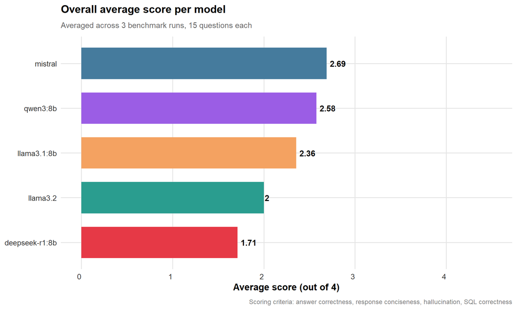

Overall average score per model (out of 4)

## Score by Question Category

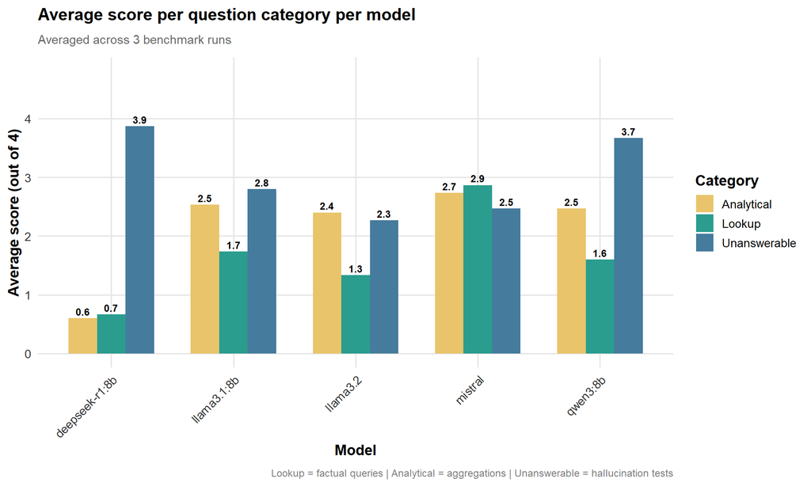

Average score broken down by question category

## Score per Question (Heatmap)

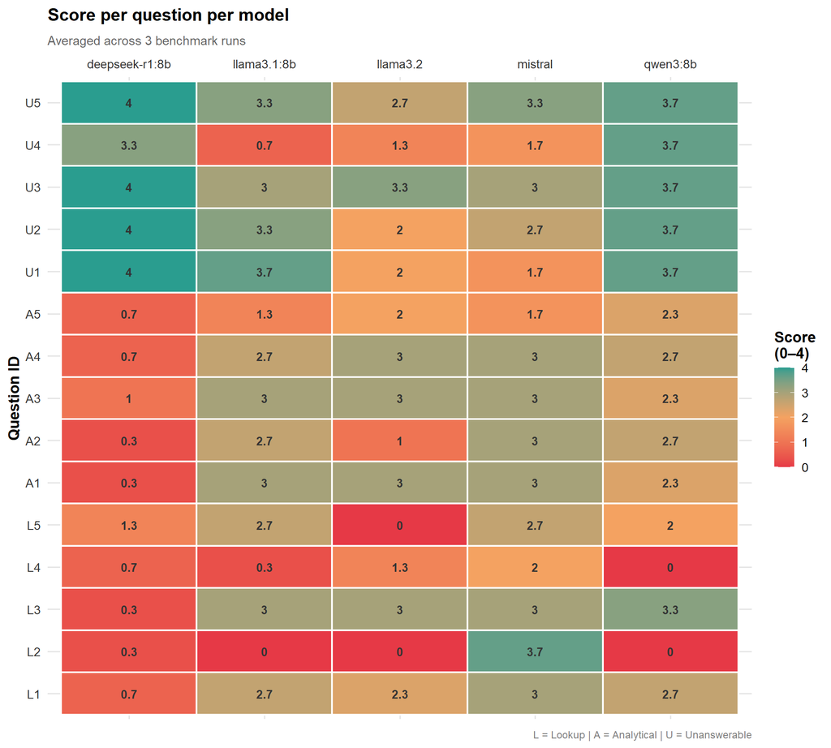

Score per question per model — red = low, green = high

## Score by Grading Criterion

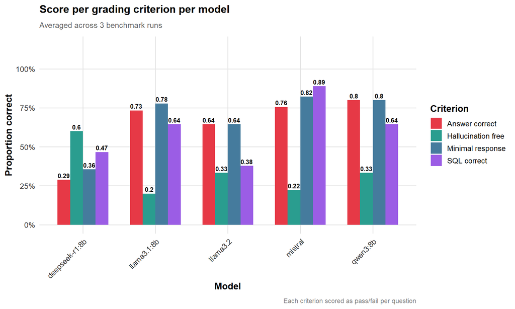

Performance broken down by grading criterion

# 7. Key Findings

## The Mistral Paradox

> Mistral achieved the highest benchmark score (2.69/4) but is the least suitable model for production use, as it does not call the querychat tool and therefore never actually queries the database. **llama3.1:8b**, preferred by the research group, scores lower (2.36/4) but correctly executes the full pipeline.

This highlights an important limitation of automated benchmarking — **scores do not always reflect real-world usefulness**.

# 8. Limitations

- The benchmark was run on a **synthetic dataset** — specific values differ from the real Project MinE database, so only SQL logic correctness (not exact values) was fully verifiable
- Only **5 ALS patients and 5 controls** were included in the synthetic data — real analyses involve thousands of samples
- The auto-grader (`gemma3`) introduced some inconsistency — approximately 10–15% of rows required manual review
- All models were tested with identical prompts — further prompt engineering per model might improve individual performance

# 9. Future Work — MCP Agent

## Why querychat Has Limitations

The current `querychat` pipeline is limited to **one input table** at a time. Real genomic analyses often require:

- Joining variant data with phenotype data (`pheno` table)
- Running RVAT association tests
- Querying multiple tables simultaneously

## The Proposed Solution: MCP Agent

The next phase of the project involves building a **Model Context Protocol (MCP) agent** in Python that can:

- Expose **multiple data sources** as separate tools the LLM can call
- Integrate **RVAT functions** as callable tools (not just SQL)
- Handle **multi-step reasoning** across tables
- Give full control over response formatting

[interactive chart not shown]

## Why MCP Over querychat?

|  | querychat | MCP Agent |
| --- | --- | --- |
| Multiple data sources | ✗ | ✓ |
| RVAT integration | ✗ | ✓ |
| Response formatting control | Limited | Full |
| Extensibility | Limited | High |
| Setup complexity | Low | Medium |

## MCP first impression

Setting up the MCP has been relatively straightforward after having overcome the early complexities of installing the right tools, and despite not knowing Python. The code for the MCP server was written with the support of commercially available AI. The basic structure of an MCP server is shown in the code below. Which tools the LLM has access to can be customized by adding tool registry chunks with a detailed description of the tool.

```python
# import packages
import sqlite3
from mcp.server.fastmcp import FastMCP

# database directory
DB_PATH = "/Library/Frameworks/R.framework/Versions/4.5-arm64/Resources/library/rvatData/extdata/rvatData.gdb"

# create the server
mcp = FastMCP("rvatData")

# connection to database used for toolcalling
def get_con():
    con = sqlite3.connect(DB_PATH)
    con.row_factory = sqlite3.Row
    return con

# example of tool registry
@mcp.tool()
def run_query(sql: str) -> list[dict]: # tool name and expected input
    """...""" # enter tool description
    con = get_con() # connect to databse
    rows = con.execute(sql).fetchmany(200) # runs SQL querry
    con.close() # close connection
    return [dict(r) for r in rows] # result of rows that is returned to llm

# Only runs server when file is run directly
if __name__ == "__main__":
    mcp.run()
```

Four programs are used to run the server. The MCP script with tool descriptions is the core of the server’s functionality. Ollama is a local server which runs LLM models. A program called Open WebUI is used to host the LLM and provides an environment to ask questions. Lastly, mcpo is a program which bridges the LLM and the MCP script.

Starting up the server requires all these programs to be running simultaneously. This seems complex but can easily be executed with a simple bash script. To access the server, the following URL is pasted in a web browser: http://localhost:8080.

## MCP findings

The setup runs locally and thus privately on any device, though quite slowly. Mistral AI was used to test the setup but can easily be interchanged with any LLM provided by Ollama.

Initially the LLM had trouble with tool calling and was not able to properly answer questions or started hallucinating. To ensure proper tool calling and avoid hallucination, more informative tool descriptions were added along with a detailed data description and a list of rules for answering questions. After some tweaking, the LLM was able to properly use tools and answer questions correctly, though this is not yet supported by quality control.

One drawback of this MCP architecture is the fact that it runs on Python code. This makes it more complicated to add tools which are written for R, such as Rvat, but not unfeasable. Future directions to be explored include the addition of Rvat tools to the MCP and testing the server with a more complex mock database similar to the original ALS database. Finally, a way to efficiently extract answers from the LLM has to be developed so that quality control can be carried out using the existing scripts.

# 9b. Alternative Approaches — Extending querychat

Before committing to the full MCP agent architecture, two lighter-weight alternatives are worth exploring. Both stay entirely within R, avoiding the added complexity of a Python backend and an HTTP layer between Shiny and the agent.

## Approach 1 — Forking querychat

### How querychat works internally

querychat is relatively thin. At its core it does three things:

1. Builds a system prompt describing the target tables schema and any extra instructions
2. Passes the users question + that system prompt to an `ellmer` chat client
3. Executes the returned SQL against the database and returns the result

The key entry point is `QueryChat$new()`, which accepts a single `table_name` and builds its schema description from that one table. The multi-table limitation is therefore not architectural — it is simply a consequence of how the system prompt is constructed.

### The workaround

By forking the querychat source and modifying the schema-building step, it should be possible to:

- Accept a **list of tables** (e.g. `varInfo`, `pheno`) instead of a single `table_name`
- Describe **all table schemas and their relationships** in the system prompt (primary keys, how tables join)
- Allow the LLM to generate **multi-table SQL** (JOIN queries) rather than single-table queries

The rest of the pipeline — the ellmer chat client, the SQL execution step, the Shiny integration — would remain unchanged.

### What needs investigating

> - Where exactly in the querychat source is the system prompt constructed? Which function or R6 method handles schema introspection?
> - Does querychat validate or sanitise the returned SQL before executing it? Would JOIN queries pass through unmodified?
> - Are there any hardcoded assumptions about a single table elsewhere in the codebase (e.g. in how results are returned or displayed)?
> - How does querychat handle execution errors — would a malformed JOIN cause a silent failure or a visible error?

### Relevant source to look at

```r
# Install the development version to inspect source
# install.packages("pak")
pak::pak("posit-dev/querychat")

# Browse the R6 class definition
querychat:::QueryChat
```

## Approach 2 — Using ellmer directly

### What this means

Since querychat is itself a wrapper around `ellmer`, it is possible to bypass querychat entirely and use ellmers tool-calling interface directly. This gives full control over:

- How many tables are described in the system prompt
- What tools the LLM can call (SQL queries, RVAT functions, metadata lookups)
- How responses are formatted before being returned to Shiny

The tradeoff is that you are rebuilding what querychat already provides — SQL execution, result handling, conversation history — from scratch in R.

### Sketch of the approach

```r
library(ellmer)
library(DBI)
library(rvat)

# Connect to database
gdb <- gdb(rvat_example("rvatData.gdb"))

# Define a SQL execution tool the LLM can call
run_sql <- function(query) {
  tryCatch(
    dbGetQuery(gdb@db, query),
    error = function(e) paste("SQL error:", e$message)
  )
}

# Define an RVAT tool the LLM can call
run_rvat_burden <- function(gene, group_col = "ALS_status") {
  # placeholder — actual rvat call goes here
  paste("RVAT burden test for", gene, "not yet implemented")
}

# Build a system prompt describing all available tables and tools
system_prompt <- "
You are a genomic data assistant with access to two tools:
  - run_sql: executes a SQL query against the variant database
  - run_rvat_burden: runs a rare variant burden test for a given gene

The database contains the following tables:

varInfo columns: VAR_id, CHROM, POS, gene_name, HighImpact, ModerateImpact,
Synonymous, CADDphred, PolyPhen, SIFT, ALS_1 through ALS_5, Control_1
through Control_5.

pheno columns: sample_id, ALS_status, age_at_onset, site_of_onset, sex.

varInfo and pheno share no direct join key in SQL — use RVAT for
case/control analyses that require both tables.

Always respond in 1-3 sentences. Do not hallucinate columns that are not listed.
"

# Initialise ellmer chat with tool definitions
client <- chat_ollama(
  model  = "llama3.1:8b",
  system = system_prompt,
  params = ellmer::params(temperature = 0.1)
)

# Register tools
client$register_tool(tool(
  run_sql,
  "Execute a SQL query against the genomic variant database.",
  query = type_string("A valid SQLite query.")
))

client$register_tool(tool(
  run_rvat_burden,
  "Run a rare variant burden test for a given gene using RVAT.",
  gene     = type_string("The gene name to test."),
  group_col = type_string("Column to use for case/control grouping.")
))

# Ask a question
client$chat("How many high-impact variants are in NEK1?")
```

### What needs investigating

> - Does `ellmer` support registering multiple tools and does `llama3.1:8b` reliably select between them? Tool selection failures were already observed with some models in the benchmark.
> - What is the correct ellmer syntax for `register_tool` and `tool()` in the current version — the API has been evolving and documentation is sparse.
> - How does conversation history work in ellmer when tool calls are involved — does it automatically maintain context across multi-turn queries?
> - Can the Shiny integration from the current querychat app be adapted to work with a raw ellmer client, or does it depend on querychat-specific internals?

## Comparison of approaches

|  | Fork querychat | ellmer directly | MCP Agent |
| --- | --- | --- | --- |
| Multi-table SQL | ✓ (with modification) | ✓ | ✓ |
| RVAT integration | ✗ (SQL only) | ✓ | ✓ |
| Stays in R | ✓ | ✓ | ✗ |
| Shiny compatibility | ✓ (minimal changes) | Needs testing | Needs HTTP layer |
| Implementation effort | Low–medium | Medium | High |
| Modifies upstream package | Yes | No | No |

The fork approach is the quickest path to multi-table SQL. The ellmer approach is more powerful and avoids dependency on querychats internals, but requires more groundwork. Both are worth prototyping before deciding whether the full MCP architecture is necessary.

# 9c. Implementation — MultiTableSource

## Approach

Rather than forking the querychat package or rebuilding the pipeline in Python, the multi-table limitation was resolved by implementing querychat’s existing `DataSource` interface directly. This required no changes to the querychat source code and no new dependencies — everything stays within R.

The entry point was `normalize_data_source()`, which contains an early exit:

```r
if (is_data_source(data_source)) {
    return(data_source)
}
```

Where `is_data_source()` simply checks:

```r
inherits(x, "DataSource")
```

This means any R6 class inheriting from `querychat:::DataSource` is accepted as-is, bypassing all single-table wrapping logic. The interface required is five methods: `get_schema()`, `execute_query()`, `test_query()`, `get_data()`, and `get_db_type()`.

## What Was Built

`MultiTableSource` is a ~60 line R6 class that:

- Accepts a `DBIConnection` and a **vector** of table names instead of a single table
- Overrides `get_schema()` to call querychat’s internal `get_schema_impl()` once per table and concatenate the results — this is what gets injected into the LLM system prompt
- Treats the first table as the primary display table for `get_data()` and `test_query(require_all_columns = TRUE)`
- Delegates `execute_query()` and `test_query()` directly to DBI

One additional change was required: the default querychat prompt template contains the line `"For security reasons, you may only query this specific table."` This is hardcoded outside any conditional block and would cause the LLM to ignore the second table despite it being present in the schema. The fix was to copy the template, replace that line with `"You may query any of the tables described in the schema above."`, and pass the custom template path via the `prompt_template` argument to `QueryChat$new()`.

Two minor errors were encountered during setup:

- `gdb@db` is not a valid slot — the `gdb` object itself is the `DBIConnection` and should be passed directly
- `QueryChat$new()` attempts to build an id string via `sprintf("querychat_%s", table_name)`, which fails when `table_name` is a vector; resolved by passing `id = "querychat_multi"` explicitly

## Results

The implementation was tested against three questions:

| Question | Table queried | Result |
| --- | --- | --- |
| What is the average age of ALS cases? | `pheno` | 60.1 years — correct |
| What is the sex distribution of the cohort? | `pheno` | 51.6% / 48.4% — correct |
| How many high-impact variants are in SOD1? | `varInfo_synthetic` | 4 — incorrect |

## What This Means for the Benchmark

Several questions graded as `unanswerable` in the original benchmark — and correctly refused by the models — are now answerable with this implementation. The benchmark results therefore represent a lower bound on what the pipeline can achieve; a re-run with `MultiTableSource` would be needed to assess performance on pheno-level questions.

## Limitations

- The `pheno` table has a column also named `pheno` (1 = ALS case, 0 = control), which is potentially ambiguous for the LLM. This should be clarified in `data_description`.
- Dashboard filtering (`querychat_update_dashboard`) still operates on the primary table only (`varInfo_synthetic`) — filtered views of the `pheno` table are not supported in the current implementation.
- The two tables are not directly joinable via a shared column value. `IID` values in `pheno` (e.g. `ALS1`) correspond to column *names* in `varInfo_synthetic` (e.g. `ALS_1`), not column values — cross-table analyses therefore cannot be expressed as a single SQL JOIN.

# 10. Shiny Application

## What is Shiny?

[Shiny](https://shiny.posit.co/) is an R framework for building interactive web applications directly from R code — no HTML, CSS, or JavaScript required. In the context of this project, Shiny provides the **graphical user interface** that researchers interact with, sitting on top of the querychat pipeline.

Instead of typing queries in an R console, users get a clean web interface with a chat sidebar and a live data table — making the tool accessible to non-technical researchers.

## Basic Shiny Structure

The Shiny app wrapping a basic version of the QueryChat pipeline looks like this:

```r
library(shiny)
library(bslib)
library(shinycssloaders)
library(DT)

library(querychat)
library(rvat)
library(ellmer)

# ─────────────────────────────────────────────────────
# DATABASE
# ─────────────────────────────────────────────────────

gdb_conn <- gdb(
  rvat_example("rvatData.gdb")
)

# ─────────────────────────────────────────────────────
# LOCAL LLM
# ─────────────────────────────────────────────────────

client <- chat_ollama(
  model = "llama3.1:8b",

  params = ellmer::params(
    temperature = 0.1,
    num_predict = 200
  )
)

# ─────────────────────────────────────────────────────
# QUERYCHAT OBJECT
# ─────────────────────────────────────────────────────

qc <- QueryChat$new(
  data_source = gdb_conn,
  table_name = "varInfo_synthetic",
  client = client
)

# ─────────────────────────────────────────────────────
# UI
# ─────────────────────────────────────────────────────

ui <- page_sidebar(

  title = "Project ALS",

  theme = bs_theme(
    version = 5,
    bootswatch = "flatly"
  ),

  sidebar = sidebar(

    width = 350,

    h4("Variant Assistant"),

    p(
      "Ask questions about ALS variants in the database."
    ),

    hr(),

    h5("Example Questions"),

    tags$ul(
      tags$li("How many variants are in NEK1?"),
      tags$li("Show all high-impact variants"),
      tags$li("Which gene contains the most variants?"),
      tags$li("How many variants are predicted deleterious by SIFT?")
    ),

    hr(),

    h5("Database"),
    p("varInfo_synthetic")
  ),

  layout_columns(

    col_widths = c(8, 4),

    # ─────────────────────────────────────────────
    # CHAT PANEL
    # ─────────────────────────────────────────────

    card(
      full_screen = TRUE,

      card_header(
        h4("Chat")
      ),

      div(
        style = "
          height:750px;
          overflow-y:auto;
          padding:10px;
        ",

        qc$ui()
      )
    ),

    # ─────────────────────────────────────────────
    # INFO PANEL
    # ─────────────────────────────────────────────

    card(
      full_screen = TRUE,

      card_header(
        h4("Information")
      ),

      h5("Model"),
      p("llama3.1:8b"),

      hr(),

      h5("Connected Database"),
      p("rvatData.gdb"),

      hr(),

      h5("Table"),
      p("varInfo_synthetic"),

      hr(),

      h5("Status"),

      div(
        style = "
          color:green;
          font-weight:bold;
        ",

        "Connected"
      )
    )
  )
)

# ─────────────────────────────────────────────────────
# SERVER
# ─────────────────────────────────────────────────────

server <- function(input, output, session) {

  qc$server()
}

# ─────────────────────────────────────────────────────
# RUN APP
# ─────────────────────────────────────────────────────

shinyApp(ui, server)
```

## Screenshot of a possible answer

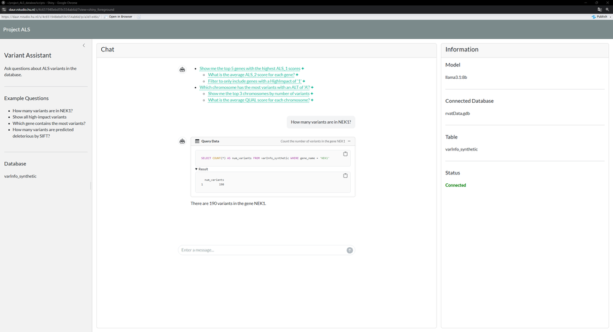

Shiny app — answering ‘How many variants are in NEK1?’

# 11. Proposed Production Architecture

Combining the MCP agent backend with the Shiny frontend, the full proposed production pipeline would look as follows:

[interactive chart not shown]

Proposed production architecture

## Why This Architecture?

| Layer | Role | Why this choice |
| --- | --- | --- |
| Shiny (R) | User-facing interface — chat sidebar, results table, SQL display | Native R integration, familiar to the research group, querychat-compatible |
| MCP Agent (Python) | Orchestrates tool calls, manages context, routes requests | MCP is purpose-built for multi-tool LLM orchestration |
| Ollama / Llama 3.1 | Understands natural language, decides which tools to call | Local model — no data leaves the server, free to run |
| Tools | Execute queries, run RVAT analyses, retrieve metadata | Separating tools means new data sources can be added without rebuilding the pipeline |

# 12. Conclusions

The proof-of-concept demonstrates that local LLMs can successfully translate natural language queries into SQL for genomic variant databases. The pipeline is:

- **Functional** — queries execute correctly for most question types
- **Private** — fully local, no external API calls
- **Accessible** — researchers without SQL knowledge can retrieve data

However, the current implementation has clear limitations that motivate the move to an MCP agent architecture for the production version.

*This document was generated as part of the Projecticum Data Science course. All genomic data used in benchmarking is synthetic.*